# Regressão Linear Bayesiana

Jose Storopoli

A principal ferramenta para computação Bayesiana é a linguagem probabilística [`Stan`](https://mc-stan.org/). O nome homenageia [Stanislaw Ulam](https://en.wikipedia.org/wiki/Stanislaw_Ulam): um matemático polonês membro do projeto Manhattan (bomba atômica americana) e um dos principais criadores do método de Monte Carlo de simulação. `Stan` foi lançado em 2012 e é a principal ferramenta utilizada hoje para inferência estatística Bayesiana. O programa roda em linguagem `C++`, mas possui interfaces para `R`, `Python`, `MATLAB`, `Julia`, `Stata`, `Mathematica`, `Scala` e `Shell`.

O problema do `Stan` é que ele é uma **linguagem de programação** e, portanto, possui um acesso dificultado a não-programadores. Abaixo um código que mostra como é um programa escrito em `Stan`:

```r
data {
  int<lower=0> N;
  vector<lower=0, upper=200>[N] kid_score;
  vector<lower=0, upper=200>[N] mom_iq;
}
parameters {
  vector[2] beta;
  real<lower=0> sigma;
}
model {
  sigma ~ cauchy(0, 2.5);
  kid_score ~ normal(beta[1] + beta[2] * mom_iq, sigma);
}
```

## `rstanarm`

Para remediar isso, temos interfaces abstratas que interpretam a intenção do usuário e lidam com a parte mais *obral* de codificação. A principal delas é o pacote `rstanarm`, que a etmologia pode ser quebrada em:

- `r`: pacote para `R`
- `stan`: usa a linguagem probabilística `Stan`
- `arm`: acrônimo para *Applied Regression Modeling*

O código anterior de `Stan` ficaria assim no `rstanarm`:

```r
stan_glm(kid_score ~ mom_iq, data = dataset)
```

# Regressão Linear

A ideia aqui é modelar uma variável dependente sendo a combinação linear de variáveis independentes.

$$y = \alpha + \boldsymbol{\beta} \textbf{X} + \epsilon$$

Aonde $y$ é a variável dependente, $\alpha$ um constante, $\boldsymbol{\beta}$ um vetor de coeficientes, $\textbf{X}$ uma matriz de dados e $\epsilon$ o erro do modelo.

## Exemplo - Score de QI de crianças

Vamos aplicar modelagem estatística Bayesiana em um *dataset* famoso chamado `kidiq`. São dados de uma *survey* de mulheres adultas norte-americanas e seus respectivos filhos. Datado de 2007 possui 434 observações e 4 variáveis:

- `kid_score`: QI da criança;
- `mom_hs`: binária (0 ou 1) se a mãe possui diploma de ensino médio;
- `mom_iq`: QI da mãe; e
- `mom_age`: idade da mãe.

Vamos usar 4 modelos para modelar QI da criança (`kid_score`). Os primeiros dois modelos terão apenas um único preditor (`mom_hs` ou `mom_iq`), o terceiro usará dois preditores (`mom_hs + mom_iq`) e o quarto incluirá uma interação entre esses dois preditores (`mom_hs * mom_iq`),

### Descritivo das variáveis

Antes de tudo, analise **SEMPRE** os dados em mãos. Graficamente e com tabelas.

#### Gráficos

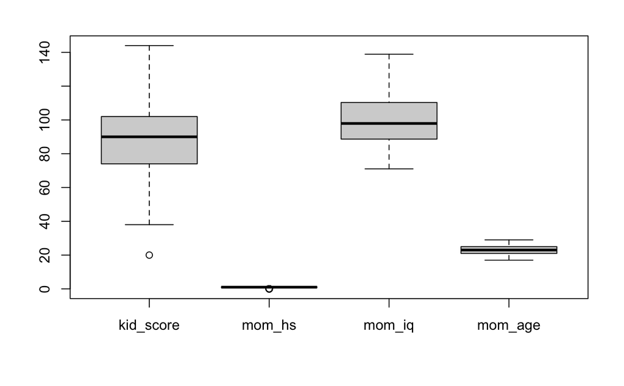

```r
# Detectar quantos cores/processadores
options(mc.cores = parallel::detectCores())
options(Ncpus = parallel::detectCores())

library(rstanarm)
data(kidiq)

boxplot(kidiq)
```

#### Tabelas

Pessoalmente uso o pacote `skimr` com a função `skim()`:

```r
library(skimr)

skim(kidiq)
```

```
── Data Summary ────────────────────────
                           Values
Name                       kidiq
Number of rows             434
Number of columns          4
_______________________
Column type frequency:
  numeric                  4
________________________
Group variables            None

── Variable type: numeric ───────────────────────────────────────────────────────────────────────
  skim_variable n_missing complete_rate    mean     sd    p0   p25   p50   p75  p100 hist
1 kid_score             0             1  86.8   20.4    20    74    90    102   144  ▁▃▇▇▁
2 mom_hs                0             1   0.786  0.411   0     1     1      1     1  ▂▁▁▁▇
3 mom_iq                0             1 100.    15.0    71.0  88.7  97.9  110.  139. ▃▇▆▃▂
4 mom_age               0             1  22.8    2.70   17    21    23     25    29  ▂▅▇▃▂
```

### Modelo 1 - `mom_hs`

Primeiro modelo é apenas a variável `mom_hs` como preditora:

```r
model_1 <- stan_glm(
  kid_score ~ mom_hs,
  data = kidiq
  )
```

```
starting worker pid=15765 on localhost:11759 at 11:10:43.318
starting worker pid=15783 on localhost:11759 at 11:10:43.553
starting worker pid=15801 on localhost:11759 at 11:10:43.785
starting worker pid=15819 on localhost:11759 at 11:10:43.992
```

Para ver os valores estimados pelo modelo usamos a função `print`:

```r
print(model_1)
```

```
stan_glm
 family:       gaussian [identity]
 formula:      kid_score ~ mom_hs
 observations: 434
 predictors:   2
------
            Median MAD_SD
(Intercept) 77.6    2.1
mom_hs      11.7    2.4

Auxiliary parameter(s):
      Median MAD_SD
sigma 19.9    0.7

------
* For help interpreting the printed output see ?print.stanreg
* For info on the priors used see ?prior_summary.stanreg
```

Além disso, temos a função `summary` que traz tudo que queremos:

```r
summary(model_1)
```

```
Model Info:
 function:     stan_glm
 family:       gaussian [identity]
 formula:      kid_score ~ mom_hs
 algorithm:    sampling
 sample:       4000 (posterior sample size)
 priors:       see help('prior_summary')
 observations: 434
 predictors:   2

Estimates:
              mean   sd   10%   50%   90%
(Intercept) 77.6    2.1 75.0  77.6  80.2
mom_hs      11.7    2.3  8.8  11.7  14.6
sigma       19.9    0.7 19.0  19.9  20.7

Fit Diagnostics:
           mean   sd   10%   50%   90%
mean_PPD 86.8    1.3 85.1  86.8  88.5

The mean_ppd is the sample average posterior predictive distribution of the outcome variable (for details see help('summary.stanreg')).

MCMC diagnostics
              mcse Rhat n_eff
(Intercept)   0.0  1.0  4179
mom_hs        0.0  1.0  4237
sigma         0.0  1.0  4063
mean_PPD      0.0  1.0  3834
log-posterior 0.0  1.0  2016

For each parameter, mcse is Monte Carlo standard error, n_eff is a crude measure of effective sample size, and Rhat is the potential scale reduction factor on split chains (at convergence Rhat=1).
```

### Modelo 2 - `mom_iq`

Segundo modelo é apenas a variável `mom_iq` como preditora:

```r
model_2 <- stan_glm(
  kid_score ~ mom_iq,
  data = kidiq
  )
```

```
starting worker pid=15849 on localhost:11759 at 11:10:57.719
starting worker pid=15867 on localhost:11759 at 11:10:58.003
starting worker pid=15885 on localhost:11759 at 11:10:58.303
starting worker pid=15903 on localhost:11759 at 11:10:58.626
```

Podemos também especificar os percentis desejados no sumário:

```r
summary(model_2, probs = c(0.025, 0.975))
```

```
Model Info:
 function:     stan_glm
 family:       gaussian [identity]
 formula:      kid_score ~ mom_iq
 algorithm:    sampling
 sample:       4000 (posterior sample size)
 priors:       see help('prior_summary')
 observations: 434
 predictors:   2

Estimates:
              mean   sd   2.5%   98%
(Intercept) 26.0    6.0 13.9   37.5
mom_iq       0.6    0.1  0.5    0.7
sigma       18.3    0.6 17.2   19.6

Fit Diagnostics:
           mean   sd   2.5%   98%
mean_PPD 86.8    1.2 84.4   89.3

The mean_ppd is the sample average posterior predictive distribution of the outcome variable (for details see help('summary.stanreg')).

MCMC diagnostics
              mcse Rhat n_eff
(Intercept)   0.1  1.0  4008
mom_iq        0.0  1.0  4039
sigma         0.0  1.0  3289
mean_PPD      0.0  1.0  4013
log-posterior 0.0  1.0  1654

For each parameter, mcse is Monte Carlo standard error, n_eff is a crude measure of effective sample size, and Rhat is the potential scale reduction factor on split chains (at convergence Rhat=1).
```

### Modelo 3 - `mom_hs + mom_iq`

Terceiro modelo usa as duas variáveis `mom_hs` e `mom_iq` como preditoras:

```r
model_3 <- stan_glm(
  kid_score ~ mom_hs + mom_iq,
  data = kidiq
  )
```

```
starting worker pid=15936 on localhost:11759 at 11:11:14.713
starting worker pid=15954 on localhost:11759 at 11:11:15.000
starting worker pid=15972 on localhost:11759 at 11:11:15.330
starting worker pid=15992 on localhost:11759 at 11:11:15.657
```

```r
print(model_3)
```

```
stan_glm
 family:       gaussian [identity]
 formula:      kid_score ~ mom_hs + mom_iq
 observations: 434
 predictors:   3
------
            Median MAD_SD
(Intercept) 25.8    6.0
mom_hs       6.0    2.2
mom_iq       0.6    0.1

Auxiliary parameter(s):
      Median MAD_SD
sigma 18.2    0.6

------
* For help interpreting the printed output see ?print.stanreg
* For info on the priors used see ?prior_summary.stanreg
```

### Modelo 4 - `mom_hs * mom_iq`

Quarto modelo usa as duas variáveis `mom_hs` e `mom_iq` como preditoras por meio de uma interação entre as duas:

```r
model_4 <- stan_glm(
  kid_score ~ mom_hs * mom_iq,
  data = kidiq
  )
```

```
starting worker pid=16064 on localhost:11759 at 11:11:32.405
starting worker pid=16082 on localhost:11759 at 11:11:32.668
starting worker pid=16100 on localhost:11759 at 11:11:32.915
starting worker pid=16118 on localhost:11759 at 11:11:33.164
```

```r
print(model_4)
```

```
stan_glm
 family:       gaussian [identity]
 formula:      kid_score ~ mom_hs * mom_iq
 observations: 434
 predictors:   4
------
              Median MAD_SD
(Intercept)   -9.4   13.1
mom_hs        49.0   14.4
mom_iq         0.9    0.1
mom_hs:mom_iq -0.5    0.2

Auxiliary parameter(s):
      Median MAD_SD
sigma 18.0    0.6

------
* For help interpreting the printed output see ?print.stanreg
* For info on the priors used see ?prior_summary.stanreg
```

## Variáveis qualitativas

Para as variáveis qualitativas, o R usa um tipo especial de variável chamado `factor`. A codificação é em números inteiros $1,2,\dots,K$ mas a relação é distinta/nominal. Ou seja 1 é distinto de 2 e não 1 é 2x menor que 2. Não há relação quantitativa entre os valores das variáveis `factor`.

Isso resolve o problema de termos variáveis qualitativas (também chamadas de *dummy*) em modelos de regressão. Para um `factor` com $K$ quantidade de classes distintas, temos a possibilidade de criar $K-1$ coeficientes de regressão. Um para cada classe e usando uma como basal (*baseline*).

```r
library(gapminder)
levels(gapminder$continent)
```

```
[1] "Africa"   "Americas" "Asia"     "Europe"   "Oceania"
```

```r
model_5 <- stan_glm(lifeExp ~ gdpPercap + factor(continent), data = gapminder)
```

```
starting worker pid=16143 on localhost:11759 at 11:11:47.295
starting worker pid=16161 on localhost:11759 at 11:11:47.543
starting worker pid=16179 on localhost:11759 at 11:11:47.797
starting worker pid=16197 on localhost:11759 at 11:11:48.032
```

```r
print(model_5)
```

```
stan_glm
 family:       gaussian [identity]
 formula:      lifeExp ~ gdpPercap + factor(continent)
 observations: 1704
 predictors:   6
------
                          Median MAD_SD
(Intercept)               47.9    0.3
gdpPercap                  0.0    0.0
factor(continent)Americas 13.6    0.6
factor(continent)Asia      8.7    0.6
factor(continent)Europe   17.6    0.7
factor(continent)Oceania  18.1    1.8

Auxiliary parameter(s):
      Median MAD_SD
sigma 8.4    0.1

------
* For help interpreting the printed output see ?print.stanreg
* For info on the priors used see ?prior_summary.stanreg
```

*Obs: para mudar o basal de referência de um `factor` use a função `relevel()` do R.*

## Atividade Prática

Dois *datasets* estão disponíveis na pasta `datasets/`:

1. [WHO Life Expectancy Kaggle Dataset](https://www.kaggle.com/kumarajarshi/life-expectancy-who): `datasets/WHO_Life_Exp.csv`
2. [Wine Quality Kaggle Dataset](https://www.kaggle.com/uciml/red-wine-quality-cortez-et-al-2009): `datasets/Wine_Quality.csv`

### WHO Life Expectancy

Esse dataset possui 193 países nos últimos 15 anos.

#### Variáveis

- `country`
- `year`
- `status`
- `life_expectancy`
- `adult_mortality`
- `infant_deaths`
- `alcohol`
- `percentage_expenditure`
- `hepatitis_b`
- `measles`
- `bmi`
- `under_five_deaths`
- `polio`
- `total_expenditure`
- `diphtheria`
- `hiv_aids`
- `gdp`
- `population`
- `thinness_1_19_years`
- `thinness_5_9_years`
- `income_composition_of_resources`
- `schooling`

### Wine Quality Kaggle Dataset

Esse dataset possui 1599 vinhos e estão relacionados com variantes tintas do vinho “Vinho Verde” português. Para mais detalhes, consulte a referência [Cortez et al., 2009]. Devido a questões de privacidade e logística, apenas variáveis físico-químicas (entradas) e sensoriais (a saída) estão disponíveis (por exemplo, não há dados sobre os tipos de uva, marca de vinho, preço de venda do vinho, etc.).

- `fixed_acidity`
- `volatile_acidity`
- `citric_acid`
- `residual_sugar`
- `chlorides`
- `free_sulfur_dioxide`
- `total_sulfur_dioxide`
- `density`
- `p_h`
- `sulphates`
- `alcohol`
- `quality`

```r
###
```

## Referências

P. Cortez, A. Cerdeira, F. Almeida, T. Matos and J. Reis. Modeling wine preferences by data mining from physicochemical properties. In Decision Support Systems, Elsevier, 47(4):547-553, 2009.